# User_analysis_1020

qingye

2017年10月20日

# 本报告对2017-10-17用户至2017-10-30这两周的行为进行了分析

#### 包括反映用户数目的UV,反映用户活跃度的：人均PV,用户活跃时长,以及反映用户黏度的次日留存，本次报告加入了路径深度的分析，并采用多种方式作图

#### 本次报告用R语言自动化生成报告的框架搭建，今后将在此基础上不断改进优化，下次报告将加入转化方面的分析，加深对于路径方面的分析，引进异常值提醒和分析，考虑加入排名变动

## 近两周的日活跃度(UV)

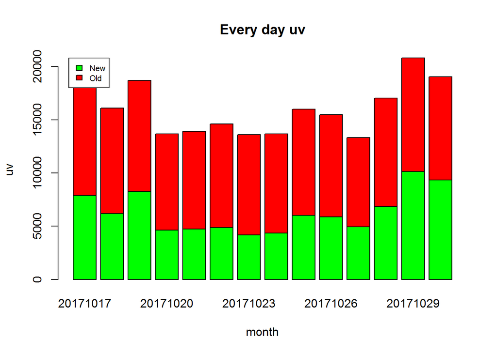

平均UV为16157,

最大UV为20805,

最大值发生在20171029

有0 天新用户在UV值上超过老用户

并没有哪天 用户UV明显高于平均值 并没有哪天 用户UV明显低于平均值

## 近两周人均PV

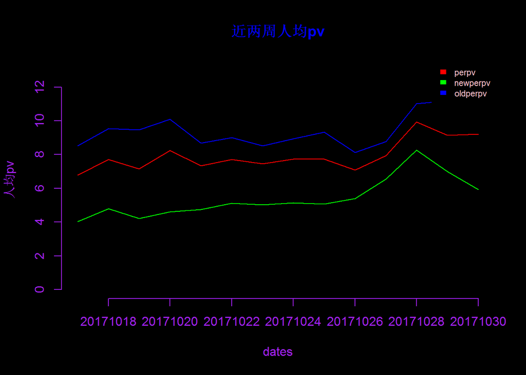

总体PV均值为7.9414456

总体PV最大值为9.9208054 最大值发生在 20171028

总体PV最小值为6.7810715 最小值发生在 20171017

新用户PV均值为5.4240399

新用户PV最大值为8.2735118 最大值发生在 20171028

新用户PV最小值为4.0309331 最小值发生在 20171017

老用户PV均值为9.5438731

老用户PV最大值为12.3782309 最大值发生在 20171030

老用户PV最小值为8.1236542 最小值发生在 20171026

有0 天新用户在人均PV值上超过老用户

20171021, 20171025, 20171026, 20171029, 20171030 新用户和老用户的趋势不一样